# 🧮 Estimativa de $\pi$ usando o Método de Monte Carlo

## Introdução

O método de Monte Carlo é uma técnica estatística baseada na geração de números aleatórios para resolver problemas matemáticos. Uma aplicação clássica desse método é a **estimação do valor de $\pi$**.

A ideia central é inscrever um círculo de raio $r = 1$ em um quadrado de lado $2r = 2$. Ao gerar pontos aleatórios dentro do quadrado e contar quantos caem dentro do círculo, podemos estimar $\pi$ usando a proporção entre os pontos dentro do círculo e o total de pontos gerados.

## Como funciona o cálculo?

Sabemos que:

- A área do quadrado é:
  $$ A_{\text{quadrado}} = (2r) \times (2r) = 4 $$
- A área do círculo de raio $r = 1$ é:
  $$ A_{\text{círculo}} = \pi r^2 = \pi $$

A razão entre essas áreas é:
$$ \frac{A_{\text{círculo}}}{A_{\text{quadrado}}} = \frac{\pi}{4} $$

Se gerarmos pontos aleatórios $(x, y)$ dentro do quadrado e contarmos quantos deles caem dentro do círculo ($x^2 + y^2 \leq 1$), podemos estimar $\pi$ como:

$$ \pi \approx 4 \times \frac{\text{número de pontos dentro do círculo}}{\text{total de pontos gerados}} $$

## Implementação do método

O código abaixo:

1. Gera pontos aleatórios $(x, y)$ no intervalo $[-1,1]$ para ambos os eixos.
2. Verifica se cada ponto está dentro do círculo.
3. Conta quantos pontos estão dentro do círculo e calcula $\pi$.
4. Exibe um gráfico com os pontos dentro (azul) e fora (vermelho) do círculo.
5. Exibe a estimativa de $\pi$.

Execute a célula abaixo para ver o resultado!

```
Estimativa de π com 10000 pontos: 3.1292
```

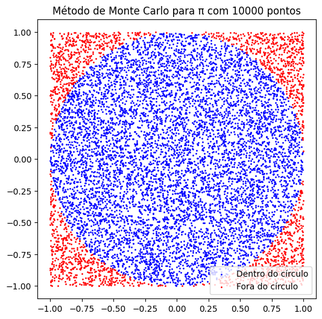

```python
import random
import matplotlib.pyplot as plt

def estimate_pi_monte_carlo(num_points):
    inside_x, inside_y = [], []
    outside_x, outside_y = [], []

    inside_circle = 0  # Contador para os pontos dentro do círculo

    for _ in range(num_points):
        x = random.uniform(-1, 1)
        y = random.uniform(-1, 1)

        if x**2 + y**2 <= 1:
            inside_x.append(x)
            inside_y.append(y)
            inside_circle += 1
        else:
            outside_x.append(x)
            outside_y.append(y)

    # Cálculo da estimativa de π
    pi_estimate = 4 * inside_circle / num_points
    print(f"Estimativa de π com {num_points} pontos: {pi_estimate}")

    # Plote os pontos
    plt.figure(figsize=(6, 6))
    plt.scatter(inside_x, inside_y, color="blue", s=1, label="Dentro do círculo")
    plt.scatter(outside_x, outside_y, color="red", s=1, label="Fora do círculo")
    plt.gca().set_aspect("equal")
    plt.legend()
    plt.title(f"Método de Monte Carlo para \u03c0 com {num_points} pontos")
    plt.show()

# Testando com 10.000 pontos
estimate_pi_monte_carlo(10000)
```